# oregon

2025-04-09

# Introduction

Utility disconnection refers to the cuts off service due to non-payment. Million of households across the United States face utility disconnections because they are unable to afford their bills, highlighting a significant and widespred issue of energy insecurity.

The following analysis aggregate utility disconnection rate data from zip codes to counties in order to reveal broader geographic patterns and disparities.

# File import - data pre-processing

To aggregating the zip code to counties level, I will use the [HUD](https://www.huduser.gov/portal/dataset/uspszip-api.html) zip code crosswalk data. This dataset provides robust way to reapportion data from zip code to geographic units, such as county level, tract level.

in some case, some zip codes crosswalk mutiple county. This data provide the address ratio for each zip code. in the following examination, i will following [Wilson and Din (2018)](https://www.huduser.gov/portal/periodicals/cityscpe/vol20num2/ch16.pdf) suggestion, remove the duplicating zip code that determines the county base on the largest ratio.

## HUD zip code crosswalk data

The following code chunk that imports [HUD](https://www.huduser.gov/portal/dataset/uspszip-api.html) zip code crosswalk data.

[HUD](https://www.huduser.gov/portal/dataset/uspszip-api.html) utilize use of the geographical information of USPS delivery points to allocate them to geographic units (such as Census Tracts or Counties). HUD establishes proportionally weighted variables, such as res_ratio, bus_ratio, etc, indicating which geographical unit each address in a certain ZIP Code is distributed.

```r
key <- "eyJ0eXAiOiJKV1QiLCJhbGciOiJSUzI1NiJ9.eyJhdWQiOiI2IiwianRpIjoiODk1ZWRlZDM4MjgwOTIyZDFlY2Q2MmYxMjMw….aw4CshBNx4n3m-y1jjt1OrNh28BaRr3mNBH51OptRk_FCNZk8Su68E06d6tZ7UViafXsSeI1-OzazhGqnMzSJA"
url <- "https://www.huduser.gov/hudapi/public/usps"

# Note that type is set to 1 which will return values for the ZIP to Tract file and query is set to VA which will return Zip Codes in Virginia
response_OR <- httr::GET(url, query = list(type = 2, query = "OR"), add_headers(Authorization = paste("Bearer", key)))

# Check for errors
if (httr::http_error(response_OR)) {
  stop("Error: ", httr::http_status(response_OR)$message)
}

# Access the output as text
outputOR <- httr::content(response_OR, as = "text", encoding = "UTF-8")

# Parse JSON content
output_json_OR <- fromJSON(outputOR)

# Convert the parsed JSON to a data frame
OR_data <- as.data.frame(output_json_OR)

# View the first few rows to understand the structure
kable(head(OR_data))
```

| data.year | data.quarter | data.input | data.crosswalk_type | data.results.zip | data.results.geoid | data.results.res_ratio | data.results.bus_ratio | data.results.oth_ratio | data.results.tot_ratio | data.results.city | data.results.state |
| --- | --- | --- | --- | --- | --- | --- | --- | --- | --- | --- | --- |
| 2024 | 4 | OR | zip-county | 97003 | 41067 | 1 | 1 | 1 | 1 | BEAVERTON | OR |
| 2024 | 4 | OR | zip-county | 97004 | 41005 | 1 | 1 | 1 | 1 | BEAVERCREEK | OR |
| 2024 | 4 | OR | zip-county | 97005 | 41067 | 1 | 1 | 1 | 1 | BEAVERTON | OR |
| 2024 | 4 | OR | zip-county | 97006 | 41067 | 1 | 1 | 1 | 1 | BEAVERTON | OR |
| 2024 | 4 | OR | zip-county | 97007 | 41067 | 1 | 1 | 1 | 1 | BEAVERTON | OR |
| 2024 | 4 | OR | zip-county | 97008 | 41067 | 1 | 1 | 1 | 1 | BEAVERTON | OR |

## Census for County_FIPS

> Since HUD file does not have County name, but it contains `data.results.geoid`, which is county of GEOID.

> [County adjacency file](https://www.census.gov/geographies/reference-files/time-series/geo/county-adjacency.html) provide the reference of GEOID in Census data, which also provide the actual county name.

> In census file, `GEOID` = `data.results.geoid` from [HUD](https://www.huduser.gov/portal/dataset/uspszip-api.html) crosswalk file.

```r
head(OR_counties)
```

```
## Simple feature collection with 6 features and 2 fields
## Geometry type: MULTIPOLYGON
## Dimension:     XY
## Bounding box:  xmin: -124.0362 ymin: 41.99302 xmax: -119.7598 ymax: 46.29083
## Geodetic CRS:  NAD83
##   GEOID                     NAME                       geometry
## 1 41035   Klamath County, Oregon MULTIPOLYGON (((-122.29 42....
## 2 41051 Multnomah County, Oregon MULTIPOLYGON (((-122.9292 4...
## 3 41043      Linn County, Oregon MULTIPOLYGON (((-123.2608 4...
## 4 41021   Gilliam County, Oregon MULTIPOLYGON (((-120.6535 4...
## 5 41007   Clatsop County, Oregon MULTIPOLYGON (((-123.6647 4...
## 6 41005 Clackamas County, Oregon MULTIPOLYGON (((-122.8679 4...
```

## Merging census and HUD crosswalk data to get the county name

| GEOID | NAME | data.year | data.quarter | data.input | data.crosswalk_type | data.results.zip | data.results.res_ratio | data.results.bus_ratio | data.results.oth_ratio | data.results.tot_ratio | data.results.city | data.results.state | geometry |
| --- | --- | --- | --- | --- | --- | --- | --- | --- | --- | --- | --- | --- | --- |
| 41001 | Baker County, Oregon | 2024 | 4 | OR | zip-county | 97870 | 1.0000000 | 1.0000000 | 1 | 1.0000000 | RICHLAND | OR | MULTIPOLYGON (((-118.5194 4… |
| 41001 | Baker County, Oregon | 2024 | 4 | OR | zip-county | 97884 | 1.0000000 | 0.0000000 | 1 | 1.0000000 | UNITY | OR | MULTIPOLYGON (((-118.5194 4… |
| 41001 | Baker County, Oregon | 2024 | 4 | OR | zip-county | 97867 | 0.1189189 | 0.2000000 | 0 | 0.1196809 | NORTH POWDER | OR | MULTIPOLYGON (((-118.5194 4… |
| 41001 | Baker County, Oregon | 2024 | 4 | OR | zip-county | 97877 | 0.8724083 | 0.3333333 | 1 | 0.8700475 | SUMPTER | OR | MULTIPOLYGON (((-118.5194 4… |
| 41001 | Baker County, Oregon | 2024 | 4 | OR | zip-county | 97837 | 1.0000000 | 0.0000000 | 0 | 1.0000000 | HEREFORD | OR | MULTIPOLYGON (((-118.5194 4… |
| 41001 | Baker County, Oregon | 2024 | 4 | OR | zip-county | 97834 | 1.0000000 | 1.0000000 | 1 | 1.0000000 | HALFWAY | OR | MULTIPOLYGON (((-118.5194 4… |

# Removing the duplicate zip code

Sometimes, Zip code do not corresponds to administrative boundaries, such as county, city, and tract (Din, A. 2021; Wilson, R., & Din, A. 2018; Din, A., & Wilson, R. 2020). Therefore, duplicate zip code will exist.

To address duplicating zip code, it need to determine the zip code in certian county. I will following [Wilson and Din (2018)](https://www.huduser.gov/portal/periodicals/cityscpe/vol20num2/ch16.pdf) suggestion, remove the duplicating zip code that determines the county base on the largest ratio.

```r
# Remove duplicates and keep rows with the maximum data.results.tot_ratio for each ZIP code

filtered_data_OR <- merged_data_or %>%
  group_by(data.results.zip) %>%
  filter(data.results.tot_ratio == max(data.results.tot_ratio)) %>%
  ungroup() %>%
  select(-data.year, -data.quarter, -data.results.state)

# View the filtered data
kable(head(filtered_data_OR))
```

| GEOID | NAME | data.input | data.crosswalk_type | data.results.zip | data.results.res_ratio | data.results.bus_ratio | data.results.oth_ratio | data.results.tot_ratio | data.results.city | geometry |
| --- | --- | --- | --- | --- | --- | --- | --- | --- | --- | --- |
| 41001 | Baker County, Oregon | OR | zip-county | 97870 | 1.0000000 | 1.0000000 | 1 | 1.0000000 | RICHLAND | MULTIPOLYGON (((-118.5194 4… |
| 41001 | Baker County, Oregon | OR | zip-county | 97884 | 1.0000000 | 0.0000000 | 1 | 1.0000000 | UNITY | MULTIPOLYGON (((-118.5194 4… |
| 41001 | Baker County, Oregon | OR | zip-county | 97877 | 0.8724083 | 0.3333333 | 1 | 0.8700475 | SUMPTER | MULTIPOLYGON (((-118.5194 4… |
| 41001 | Baker County, Oregon | OR | zip-county | 97837 | 1.0000000 | 0.0000000 | 0 | 1.0000000 | HEREFORD | MULTIPOLYGON (((-118.5194 4… |
| 41001 | Baker County, Oregon | OR | zip-county | 97834 | 1.0000000 | 1.0000000 | 1 | 1.0000000 | HALFWAY | MULTIPOLYGON (((-118.5194 4… |
| 41001 | Baker County, Oregon | OR | zip-county | 97907 | 0.9429280 | 0.6153846 | 1 | 0.9334917 | HUNTINGTON | MULTIPOLYGON (((-118.5194 4… |

# Merging utility data with zip code data

> Merging utility with zip code data

```r
oregon <- read_csv("State-Specific Data/OR_2018-2024.csv")
# Convert both columns to character if they are not already
filtered_data_OR$data.results.zip <- as.character(filtered_data_OR$data.results.zip)
oregon$zip_code <- as.character(oregon$zip_code)

merged_utility_OR <- merge(oregon, filtered_data_OR, by.x = "zip_code", by.y = "data.results.zip", all.x = TRUE)
```

> HUD data does not have all the zip code.

## Avoiding removing those ambiguous zip code

- If ZIP code is valid ➔ `"County Name, State Abbreviation"`  
  (example: `"Baker County, OR"`)
- If ZIP code is invalid ➔ `"Invalid"`

  I checked using the [ZIP code lookup](https://www.unitedstateszipcodes.org) resources.

```r
merged_utility_OR <- merged_utility_OR %>%
  mutate(NAME = case_when(
    zip_code == 83301 ~ "Twin Falls County, Idaho",
    zip_code == 83642 ~ "Ada County, Idaho",
    zip_code == 83687 ~ "Canyon County, Idaho",
    zip_code == 97248 ~ "Invalid",
    zip_code == 97372 ~ "Invalid",
    zip_code == 97809 ~ "Baker County, Oregon",
    zip_code == 9722  ~ "Invalid",
    zip_code == 1     ~ "Invalid",
    zip_code == 2     ~ "Invalid",
    zip_code == 8     ~ "Invalid",
    TRUE ~ NAME  # ⭐️ keep the original County_Name for all others
  ),
data.results.tot_ratio = case_when(
      zip_code %in% c(83301, 83642, 83687, 97248, 97372, 97809, 9722, 1, 2, 8) ~ 1,
      TRUE ~ data.results.tot_ratio))
```

# Aggregating

this section aggregating from zip code to county level, which summaring one line per county , year, month, utility.

```r
OR_county_agg <- merged_utility_OR %>%
  group_by(NAME, year, month, utility_name) %>%
  summarise(
    total_disconnections = sum(number_of_disconnections, na.rm = TRUE),
    est_disconnections = sum(number_of_disconnections * data.results.tot_ratio, na.rm = TRUE),
    avg_disconnection_rate = mean(number_of_disconnections, na.rm = TRUE),
    difference = sum(total_disconnections - est_disconnections, na.rm = TRUE),
    PCT_DIF = case_when(
      sum(number_of_disconnections, na.rm = TRUE) == 0 & sum(number_of_disconnections, na.rm = TRUE) == 0 ~ 0,
      sum(number_of_disconnections, na.rm = TRUE) == 0 ~ NA_real_,
      TRUE ~ 100 * (sum(est_disconnections, na.rm = TRUE) - sum(number_of_disconnections, na.rm = TRUE)) / sum(number_of_disconnections, na.rm = TRUE)
    ),
    mae = abs(sum(difference, na.rm = TRUE)),
    mape = case_when(
      sum(number_of_disconnections, na.rm = TRUE) == 0 & sum(number_of_disconnections, na.rm = TRUE) == 0 ~ 0,
      sum(number_of_disconnections, na.rm = TRUE) == 0 ~ NA_real_,
      TRUE ~ abs(sum(difference, na.rm = TRUE)) / sum(number_of_disconnections, na.rm = TRUE) * 100
    ),
    .groups = "drop"
  )


kable(head(OR_county_agg))
```

| NAME | year | month | utility_name | total_disconnections | est_disconnections | avg_disconnection_rate | difference | PCT_DIF | mae | mape |
| --- | --- | --- | --- | --- | --- | --- | --- | --- | --- | --- |
| Ada County, Idaho | 2019 | January | Idaho Power | 0 | 0.0000000 | 0.000 | 0.0000000 | 0.000000 | 0.0000000 | 0.000000 |
| Baker County, Oregon | 2018 | August | Idaho Power | 7 | 6.7339667 | 0.875 | 0.2660333 | -3.800475 | 0.2660333 | 3.800475 |
| Baker County, Oregon | 2018 | December | Idaho Power | 2 | 1.9334917 | 0.250 | 0.0665083 | -3.325416 | 0.0665083 | 3.325416 |
| Baker County, Oregon | 2018 | November | Idaho Power | 2 | 1.9334917 | 0.250 | 0.0665083 | -3.325416 | 0.0665083 | 3.325416 |
| Baker County, Oregon | 2018 | October | Idaho Power | 3 | 2.8004751 | 0.375 | 0.1995249 | -6.650831 | 0.1995249 | 6.650831 |
| Baker County, Oregon | 2018 | September | Idaho Power | 1 | 0.9334917 | 0.125 | 0.0665083 | -6.650831 | 0.0665083 | 6.650831 |

[figure not shown]

```r
# Step 1: group by NAME + year，summary total_disconnections
OR_county_agg_summary <- OR_county_agg %>%
  group_by(NAME, year) %>%
  summarise(
    total_disconnections = sum(total_disconnections, na.rm = TRUE),
    .groups = "drop"
  )

# Step 2: creating grid
county_year_grid <- expand_grid(
  NAME = unique(OR_counties$NAME),
  year = unique(OR_county_agg_summary$year)
)

# Step 3: Left join
OR_county_agg_geo <- county_year_grid %>%
  left_join(OR_counties, by = "NAME") %>%
  left_join(OR_county_agg_summary, by = c("NAME", "year")) %>%
  st_as_sf()

# Step 4:
ggplot(OR_county_agg_geo) +
  geom_sf(aes(fill = total_disconnections), color = "white") +
  facet_wrap(~ year) +
  scale_fill_viridis_c(option = "plasma", trans = "sqrt", na.value = "grey80") +
  labs(
    title = "Cumulative Total Disconnections in Disconnection Estimates (2018–2024)",
    fill = "Total Disconnections",
    caption = "Source: Aggregated ZIP-to-County Estimates\nUnit: Disconnection Count Difference"
  ) +
  theme_minimal() +
    theme(
    axis.text = element_blank(),
    axis.ticks = element_blank(),
    panel.grid = element_blank()
  )
```

# Validate

The evaluate the acurancy of aggregating zip code to county, I will following Din, A., & Wilson, R. (2020) suggestion to comparing actual count (total_disconnections) and estimate.

> Measuring the impact of weighting

> To evaluate how much the weighting affected the total count:
> - I summed the **unweighted totals** (`total_disconnections`) across all counties, resulting in **119049” disconnections**.
- I summed the **weighted totals**(`est_disconnections`), yielding **117852.628280546 disconnections**.
- The **absolute difference** between the two totals was **1196.37171945398 disconnections**, indicating the net shift caused by applying HUD’s weighting.

```r
print(paste("rows - unweighted total(sum of number_of_disconnections):", sum(OR_county_agg$total_disconnections)))
```

```
## [1] "rows - unweighted total(sum of number_of_disconnections): 119049"
```

```r
print(paste("rows - weighted total(est_disconnection) :", sum(OR_county_agg$est_disconnections)))
```

```
## [1] "rows - weighted total(est_disconnection) : 117852.628280546"
```

```r
print(paste("Difference (impact of weighting):", sum(OR_county_agg$difference)))
```

```
## [1] "Difference (impact of weighting): 1196.37171945398"
```

> Relative difference To contextualize this shift, I calculated the relative difference as a percentage of the unweighted total:

```r
relative_diff_OR <-
  sum(OR_county_agg$difference, na.rm = TRUE) / sum(OR_county_agg$total_disconnections, na.rm = TRUE) * 100

print(paste("Relative Difference (%):", round(relative_diff_OR, 2), "%"))
```

```
## [1] "Relative Difference (%): 1 %"
```

The 1% relative difference indicates that applying the ZIP-to-county weighting introduces minimal deviation from the raw totals. This result supports the feasibility of using HUD’s crosswalk-based ratios to estimate disconnections at the county level, even in the absence of point-level utility data.

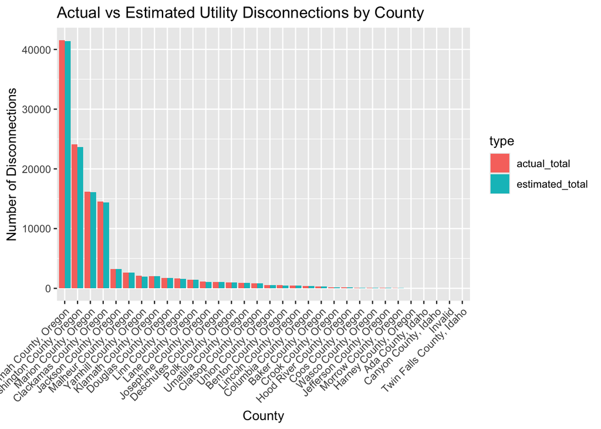

```r
# Create a summarized table: actual vs estimated
county_comparison <- OR_county_agg %>%
  group_by(NAME) %>%
  summarise(
    actual_total = sum(total_disconnections, na.rm = TRUE),
    estimated_total = sum(est_disconnections, na.rm = TRUE)
  ) %>%
  arrange(desc(actual_total))  # move arrange() here

# Reshape for visualization
county_long <- county_comparison %>%
  pivot_longer(cols = c("actual_total", "estimated_total"),
               names_to = "type", values_to = "value")

# Plot
ggplot(county_long, aes(x = reorder(NAME, -value), y = value, fill = type)) +
  geom_col(position = "dodge") +
  labs(title = "Actual vs Estimated Utility Disconnections by County",
       x = "County", y = "Number of Disconnections") +
  theme(axis.text.x = element_text(angle = 45, hjust = 1))
```

**“Having a high kurtosis is an ideal characteristic of a difference distribution because it indicates that most of the differences are not large and are similar to the average.”**  
— *Wilson, R., & Din, A. (2018)*

## **Evaluation Metrics**

in this section, I’m gonna to **Calculate Evaluation Metrics**, which quantify the estimation error across all grouped observations (by county, month, and utility):

- **MAE (Mean Absolute Error)**: **mean of absolute differences** between `total_disconnections` and `est_disconnections`

  $$\text{Mean Absolute Error} = \frac{1}{n} \sum_{i=1}^{n} \left|
  \text{total_disconnections}_i - \text{est_disconnections}_i \right|$$
- **MAPE (Mean Absolute Percentage Error)**: mean((total_disconnections - est_disconnections) / total_disconnections ) * 100

  $$\text{Mean Percentage Error} = \frac{1}{n} \sum_{i=1}^{n} \left(
  \frac{\text{total_disconnections} -
  \text{est_disconnections}_i}{\text{total_disconnections}_i} \right)
  \times 100$$

> [Montaño, Juan, and Palmer et al](https://www.researchgate.net/publication/257812432_Using_the_R-MAPE_index_as_a_resistant_measure_of_forecast_accuracy). suggest that a MAPE below 20% indicates good accuracy.

```r
print(paste("MAE in zip code level:", round(mean(merged_utility_OR_1$mae, na.rm = TRUE), 2)))
```

```
## [1] "MAE in zip code level: 0.07"
```

```r
print(paste("MAPE (%) in zip code level:", round(mean(merged_utility_OR_1$mape, na.rm = TRUE), 2)))
```

```
## [1] "MAPE (%) in zip code level: 1.01"
```

```r
#library(Metrics)  # optional, for rmse()

# Create error columns
OR_county_agg <- OR_county_agg %>%
  mutate(
    abs_error = abs(total_disconnections - est_disconnections),
    pct_error = abs_error / ifelse(total_disconnections == 0, NA, total_disconnections)
  )

# Calculate metrics
mae <- mean(OR_county_agg$abs_error, na.rm = TRUE)
mape <- mean(OR_county_agg$pct_error, na.rm = TRUE) * 100  # percentage

print(paste("MAE:", round(mae, 2)))
```

```
## [1] "MAE: 0.67"
```

```r
print(paste("MAPE (%) in county level:", round(mape, 2)))
```

```
## [1] "MAPE (%) in county level: 1.65"
```

In general, the MAPE across Oregon State remains under this 20% threshold, only 1.65% MAPE value represents high accuracy across Oregon counties.

> The following plot visualizes the MAPE of disconnection estimates. Overall, the plot shows that MAPE values are generally below 20% for each county, indicating good accuracy.

[figure not shown]

```r
# Step 1: make sure each year have County
county_year_grid <- expand_grid(
  NAME = unique(OR_counties$NAME),
  year = unique(OR_county_agg$year)
)

# Step 2: summary error summary
county_error_summary <- OR_county_agg %>%
  group_by(NAME, year) %>%
  summarise(
    total_abs_error = sum(mae, na.rm = TRUE),
    total_disconnections = sum(total_disconnections, na.rm = TRUE),
    total_est_disconnections = sum(est_disconnections, na.rm = TRUE),
    mape = (total_abs_error / total_disconnections) * 100,  # Percent form
    .groups = "drop"
  )

# Step 3: using grid left_join，let no data be NA value
county_error_complete <- county_year_grid %>%
  left_join(county_error_summary, by = c("NAME", "year"))

# Step 4:  join spatial
county_error_map <- OR_counties %>%
  left_join(county_error_complete, by = "NAME")

# Step 5:
ggplot(county_error_map) +
  geom_sf(aes(fill = mape), color = "white") +
  facet_wrap(~ year) +
  scale_fill_viridis_c(option = "plasma", trans = "sqrt", na.value = "grey80") +
  labs(
    title = "Cumulative MAPE in Disconnection Estimates (2019–2024)",
    fill = "MAPE",
    caption = "Source: Aggregated ZIP-to-County Estimates\nUnit: Disconnection Count Difference"
  ) +
  theme_minimal() +
      theme(
    axis.text = element_blank(),
    axis.ticks = element_blank(),
    panel.grid = element_blank()
  )
```

# Limitation

In this study, when aggregating utility data from ZIP code to county levels, it is not feasible to directly validate the accuracy of the estimates.

As noted by Din and Wilson (2020), when aggregating data, it is unlikely to have point-level information available; otherwise, there would be no need to perform crosswalk processing.

Although direct validation is not possible, examining differences between estimated and actual counts may reveal additional patterns of utility disconnection rate, which can be further explored through more detailed spatial analysis.

Among 17027 ZIP code-level records, only 74 records (0.43%) showed a MAPE greater than 20% and a MAE greater than 1.

```r
kable(head(
  merged_utility_OR_1 %>%
    filter(mape >20 & mae > 1) %>%
    select( -data.results.res_ratio, -data.results.bus_ratio, -data.results.oth_ratio, -GEOID, -state)
  ))
```

| zip_code | utility_name | year | month | number_of_customers | number_of_disconnections | NAME | data.input | data.crosswalk_type | data.results.tot_ratio | data.results.city | geometry | est_disconnections | difference | PCT_DIF | mae | mape |
| --- | --- | --- | --- | --- | --- | --- | --- | --- | --- | --- | --- | --- | --- | --- | --- | --- |
| 97119 | Portland General Electric | 2023 | May | 1616 | 9 | Washington County, Oregon | OR | zip-county | 0.7771826 | GASTON | MULTIPOLYGON (((-123.4854 4… | 6.994644 | 2.005356 | -22.28174 | 2.005356 | 22.28174 |
| 97119 | Portland General Electric | 2024 | Apr | 1625 | 12 | Washington County, Oregon | OR | zip-county | 0.7771826 | GASTON | MULTIPOLYGON (((-123.4854 4… | 9.326192 | 2.673808 | -22.28174 | 2.673808 | 22.28174 |
| 97119 | Portland General Electric | 2023 | Jun | 1616 | 6 | Washington County, Oregon | OR | zip-county | 0.7771826 | GASTON | MULTIPOLYGON (((-123.4854 4… | 4.663096 | 1.336904 | -22.28174 | 1.336904 | 22.28174 |
| 97119 | Portland General Electric | 2023 | Mar | 1623 | 8 | Washington County, Oregon | OR | zip-county | 0.7771826 | GASTON | MULTIPOLYGON (((-123.4854 4… | 6.217461 | 1.782539 | -22.28174 | 1.782539 | 22.28174 |
| 97119 | Portland General Electric | 2022 | Oct | 1617 | 7 | Washington County, Oregon | OR | zip-county | 0.7771826 | GASTON | MULTIPOLYGON (((-123.4854 4… | 5.440278 | 1.559721 | -22.28174 | 1.559721 | 22.28174 |
| 97321 | Northwest Natural Gas Company | 2024 | February | 8879 | 13 | Linn County, Oregon | OR | zip-county | 0.7170187 | ALBANY | MULTIPOLYGON (((-123.2608 4… | 9.321243 | 3.678757 | -28.29813 | 3.678757 | 28.29813 |

```r
kable(
  OR_county_agg %>%
    filter(mape >20 & mae > 1) )
```

| NAME | year | month | utility_name | total_disconnections | est_disconnections | avg_disconnection_rate | difference | PCT_DIF | mae | mape | abs_error | pct_error |
| --- | --- | --- | --- | --- | --- | --- | --- | --- | --- | --- | --- | --- |

> Given the absence of point-level disconnection data, this very low error rate demonstrates strong model accuracy at the ZIP code aggregation level.

# Reference

Din, A., & Wilson, R. (2020). Crosswalking ZIP Codes to Census Geographies: Geoprocessing the U.S. Department of Housing & Urban Development’s ZIP Code Crosswalk Files. *Cityscape: A Journal of Policy Development and Research, 22*(1), 293–298. U.S. Department of Housing and Urban Development. https://www.huduser.gov/portal/periodicals/cityscpe/vol22num1/ch12.pdf

Wilson, R., & Din, A. (2018). Understanding and enhancing the U.S. Department of Housing and Urban Development’s ZIP Code Crosswalk Files. *Cityscape: A Journal of Policy Development and Research, 20*(2), 277–294. https://www.huduser.gov/portal/periodicals/cityscpe/vol20num2/ch16.pdf

Din, A. (2021). New Data Fields for HUD Aggregated USPS Administrative Data on Address Vacancies. *Cityscape*, *23*(3), 283–294. https://www.jstor.org/stable/48636236